# CPLN 590 Midterm Project – Predicting Home Sale Prices in San Francisco

Natasha Tabachnikoff & Eugene Chong

October 20, 2019

# Introduction

**What is the purpose of this project?**

The purpose of this project is to predict the sale price of homes sold in San Francisco between 2012 and 2015 using what we know about other homes sold in the city during the same time period. By relating various characteristics of homes, such as their square footage or neighborhood, to their sale prices, we develop a model that predicts the sale prices of homes with similar characteristics.

**Why should we care about it?**

For cities, is it important for tax assessment purposes to have accurate information about the market value of homes to capture rising property values and fund necessary public services. For consumers, having publicly available market value estimates on sites like Zillow helps to correct informational imbalances that negatively impact homebuyers and sellers with less information and social capital.

**What makes this a difficult exercise?**

The housing market is notoriously heterogeneous, meaning that there is a huge diversity of “products” on the market serving many different needs, wants, and capacities. Preferences fluctuate with wider demographic, cultural, and economic trends, and many markets and consumer groups overlap. Further, housing generally appreciates in value over decades and centuries, distinguishing it from consumer goods that are also much less complex. These many different traits, both internal to the structure of a home and determined by its neighborhood, all demand different prices on the market. Hedonic modeling weights all these different features and assesses their value in the aggregate based on comparable properties in the market.

**What is your overall modeling strategy?**

San Francisco has a severe housing supply crisis and has (some of) the highest housing costs in the country. To onlookers, the city’s housing market can look irrational, and the relatively low volume of sales interactions obfuscates the nuances of what homebuyers value. This project tries to predict home prices by quantifying the relationship between characteristics of homes (like physical structure, neighborhood desirability, spatial organization, and access to amenities) with the known sale prices of those homes. The first step was collecting data: we gathered and cleaned data from publicly available sources that we believed would predict the sale price of a home. We then used those data to create a multiple linear regression model to determine the relationship between those home characteristics and home sale price. Lastly, we refined and finalized our model through the process of cross-validation. We split our dataset of home sale prices into training sets and test sets, using the training sets to teach our model and using the test sets to check the quality of our predictions. We added and removed predictor variables from our model until we found the one that produced the most accurate and consistent predictions for home sale prices in San Francisco.

**Briefly summarize your results.**

Our model, based on 12 variables, was able to predict home prices with an average percent error of about 20%, with some errors for higher priced homes being much larger. These dramatic overpredictions of higher cost homes impacted the overall accuracy of our model, bringing our average absolute error to about $220,000. Our model showed minimal spatial bias – the spatial distribution of our prediction errors had a Moran’s I of 0.041. Our model did show some demographic bias, predicting home sale values more accurately in low income (MAPE = 19.1%) and majority non-white (16.6%) neighborhoods compared to in high income (21.5%) and majority white (23.9%) neighborhoods. The rest of this report will dive into the data we explored, our process for selecting and refining variables, the distribution of errors in our predictions, and a discussion of the generalizability of this model.

# Data

## Data Collection

We collected and cleaned data that we believed would predict the sale price of a home. Our final model included the variables below, though we examined many others while building and refining the model.

## Table of Summary Statistics

The table and plot below present summary statistics and distributions of values for our outcome variable and the 12 predictor variables in our model.

```r
summary <- final_sales %>%
  as.data.frame() %>%
  dplyr::select(reg_vars, -log_SalePrice) %>%
  dplyr::select_if(is.numeric)

summary_df <- data.frame(matrix(ncol = 7, nrow = 1))
names(summary_df) <- c("Variable", "Min", "1st Quartile", "Median", "Mean", "3rd Quartile", "Max")

for (i in names(summary)) {
  blah <- c(i, round(summary(summary[[i]]), 1))

  summary_df <- rbind(summary_df, blah)
}

SaleYr <- c("SaleYr",
            "Categorical",
            "Temporal",
            "Year the property was sold",
            "-",
            "-",
            "-",
            "-",
            "-",
            "-")

SaleMonth <- c("SaleMonth",
            "Categorical",
            "Temporal",
            "Month the property was sold",
            "-",
            "-",
            "-",
            "-",
            "-",
            "-")

Tree_Cover <- c("Tree_Cover",
            "Categorical",
            "Amenities",
            "Are there street trees within 20 ft of the property?",
            "-",
            "-",
            "-",
            "-",
            "-",
            "-")

nhood <- c("nhood",
           "Categorical",
           "Spatial characteristic",
           "What neighborhood is the property in?",
           "-",
           "-",
           "-",
           "-",
           "-",
           "-")

summary_df2 <- summary_df %>% filter(!is.na(Variable)) %>%
  mutate(Description = case_when(Variable == "SalePrice" ~ "Sale price of home (\\$)",
                                 Variable == "PropArea" ~ "Property area of home (sqft)",
                                 Variable == "Rooms" ~ "Number of rooms",
                                 Variable == "AgeSold" ~ "Age of property at sale",
                                 Variable == "crimes.Buffer" ~ "Number of crimes within 1/8 mile",
                                 Variable == "White_Pct" ~ "Percentage white residents in census tract",
                                 Variable == "HH_Income" ~ "Household Income in census tract (\\$)",
                                 Variable == "dist_Industr" ~ "Distance from nearest industrial zone (ft)",
                                 Variable == "lagPrice" ~ "Avg price of 5 nearest home sales (\\$)"),
         Type = "Continuous",
         Category = case_when(Variable == "SalePrice" ~ "~ Outcome Variable",
                                 Variable == "PropArea" ~ "Home characteristic",
                                 Variable == "Rooms" ~ "Home characteristic",
                                 Variable == "AgeSold" ~ "Home characteristic",
                                 Variable == "crimes.Buffer" ~ "Amenities",
                                 Variable == "White_Pct" ~ "Demographic characteristic",
                                 Variable == "HH_Income" ~ "Demographic characteristic",
                                 Variable == "dist_Industr" ~ "Spatial characteristic",
                                 Variable == "lagPrice" ~ "Spatial characteristic")) %>%
  dplyr::select(Variable, Type, Category, Description, everything()) %>%
  rbind(SaleYr, SaleMonth, Tree_Cover, nhood) %>%
  arrange(Category)


kable(summary_df2) %>%
  kable_styling("striped", full_width = TRUE, )
```

Variable

Type

Category

Description

Min

1st Quartile

Median

Mean

3rd Quartile

Max

SalePrice

Continuous

~ Outcome Variable

Sale price of home ($)

100001

695001

930003

1144667.7

1380002

4750003

crimes.Buffer

Continuous

Amenities

Number of crimes within 1/8 mile

0

38

69

86.7

106

1261

Tree_Cover

Categorical

Amenities

Are there street trees within 20 ft of the property?

White_Pct

Continuous

Demographic characteristic

Percentage white residents in census tract

7.1

29.4

50.5

47.9

65.5

86

HH_Income

Continuous

Demographic characteristic

Household Income in census tract ($)

16638

73669

92846

96372.2

120308

176875

PropArea

Continuous

Home characteristic

Property area of home (sqft)

187

1160

1496

1641.8

1973

7679

Rooms

Continuous

Home characteristic

Number of rooms

1

5

6

6.4

7

26

AgeSold

Continuous

Home characteristic

Age of property at sale

0

66

84

79.6

100

144

dist_Industr

Continuous

Spatial characteristic

Distance from nearest industrial zone (ft)

0

3990.2

8930.5

10256.6

15815.3

27190.7

lagPrice

Continuous

Spatial characteristic

Avg price of 5 nearest home sales ($)

243501.8

689001.7

975491.8

1066901.6

1314422.1

3301951.8

nhood

Categorical

Spatial characteristic

What neighborhood is the property in?

SaleYr

Categorical

Temporal

Year the property was sold

SaleMonth

Categorical

Temporal

Month the property was sold

Note that our outcome variable, Sale Price, has a long right tail, with the highest values coming in well above the 75th percentile of the data.

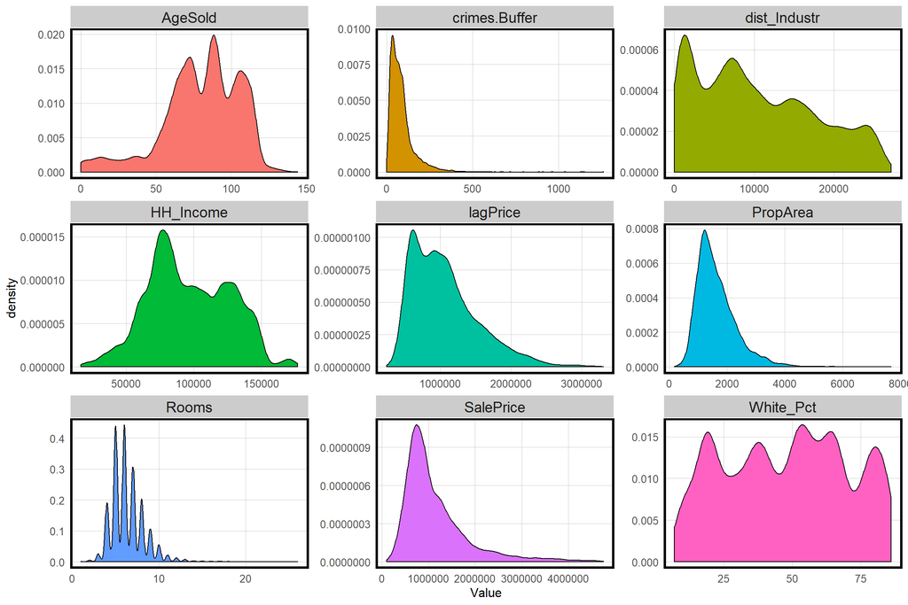

```r
summary_plot_vars <- final_sales %>%
  as.data.frame() %>%
  dplyr::select(reg_vars, -log_SalePrice) %>%
  dplyr::select_if(is.numeric) %>%
  gather(Variable, Value)

ggplot(summary_plot_vars, aes(x = Value, fill = Variable), color = "gray") +
  geom_density() +
  facet_wrap(~ Variable, ncol = 3, scales = "free") +
  theme(legend.position = "none") +
  plotTheme()
```

To normalize the distribution, we log transform the variable. We’ll use our model to predict the log of Sale Price and then exponentiate that prediction to the predicted actual Sale Price.

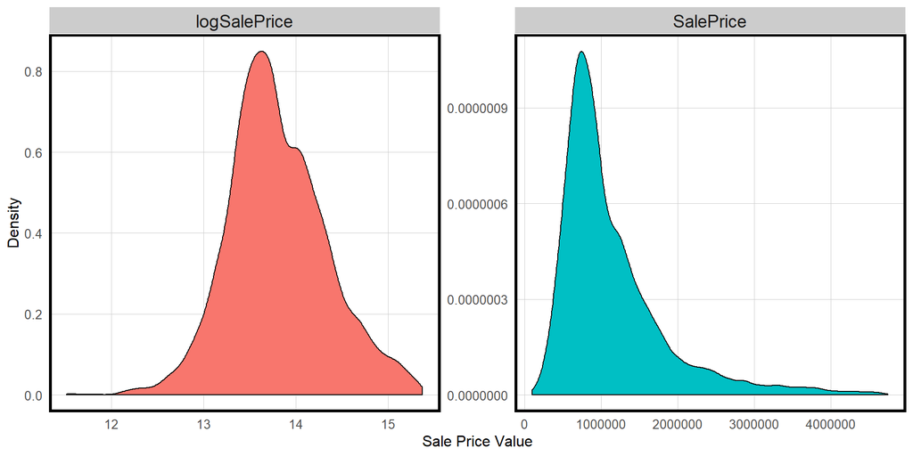

```r
ggplot(filter(summary_plot_vars, Variable == "SalePrice") %>%
         rename(SalePrice = Value) %>%
         mutate(logSalePrice = log(SalePrice)) %>%
         gather(Variable, Value),
       aes(x = Value, fill = Variable), color = "gray") +
  geom_density() +
  facet_wrap(~ Variable, scales = "free") +
  theme(legend.position = "none") +
  plotTheme() + labs(x = "Sale Price Value",
                     y = "Density")
```

## Correlation Matrix

The plot below shows the correlation between each of the variables in our model. We sought to minimize collinearity among the variables in our model, as collinear variables can rob each other of predictive power.

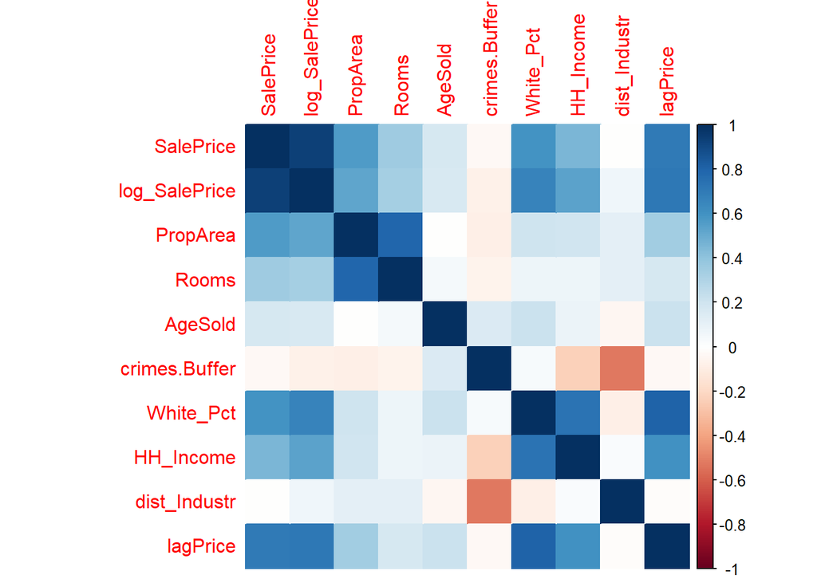

```r
corr_vars <- final_sales %>%
  as.data.frame() %>%
  dplyr::select(reg_vars) %>%
  dplyr::select_if(is.numeric) %>%
  dplyr::select(SalePrice, log_SalePrice, everything())

corr2 <- cor(corr_vars, use = "complete.obs")

corrplot(corr2, method = "color")
```

## Map of Dependent Variable

A map of our home sale dataset shows that prices are clustered.

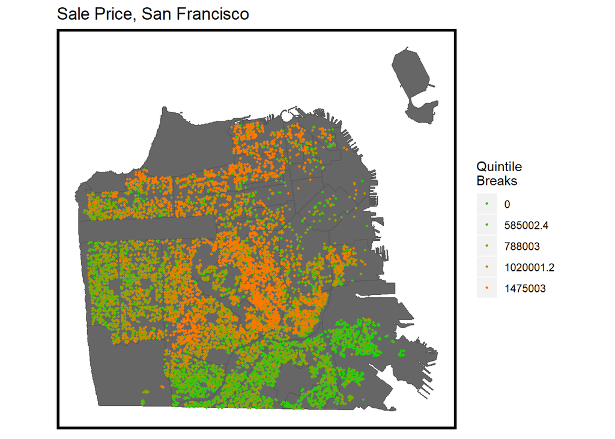

```r
SalePrice_map <- ggplot() +
  geom_sf(data = neighbs, fill = "grey40") +
  geom_sf(data = sales_sf, aes(colour = q5(SalePrice)), show.legend = "point", size = .75) +
  scale_colour_manual(values = palette5,
                   labels = qBr(sales2, "SalePrice"),
                   name = "Quintile\nBreaks") +
  labs(title = "Sale Price, San Francisco") +
  mapTheme()

SalePrice_map
```

## Independent Variables – Descriptive Plots

The plots below visualize the relationship between some of the input variables in our model and the outcome variable, sale price. For continuous variables, we use scatterplots and show each observation, along with a regression line. For categorical variables, we display bar charts and average the sale price in each category.

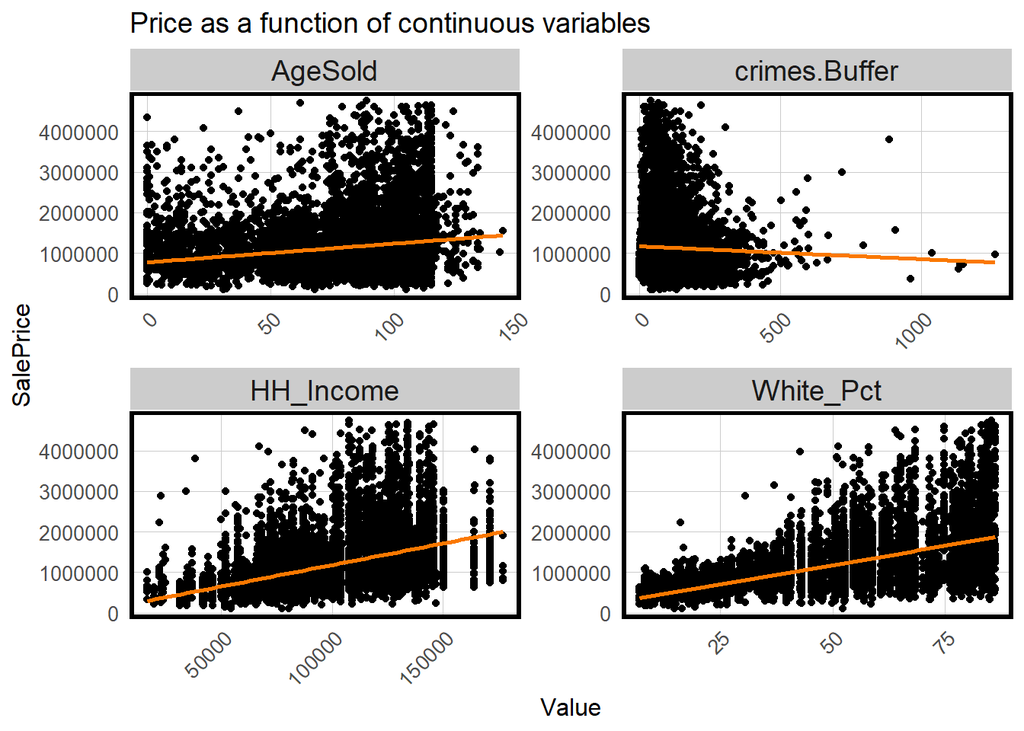

```r
final_sales_continuous_only <- final_sales %>%
  dplyr::select_if(negate(is.factor)) %>%
  dplyr::select_if(negate(is.character)) %>%
  dplyr::select(SalePrice, crimes.Buffer, White_Pct, HH_Income, AgeSold)

final_sales_continuous_only %>%
  as.data.frame() %>%
  dplyr::select(-geometry) %>%
  gather(Variable, Value, -SalePrice) %>%
   ggplot(aes(x = Value,
              y = SalePrice)) +
     geom_point() +
     geom_smooth(method = "lm", se = F, colour = "#FA7800") +
     facet_wrap(~Variable, ncol = 2, scales = "free") +
     labs(title = "Price as a function of continuous variables") +
     theme(axis.text.x = element_text(angle = 45, hjust = 1)) +
     plotTheme() + scale_y_continuous()
```

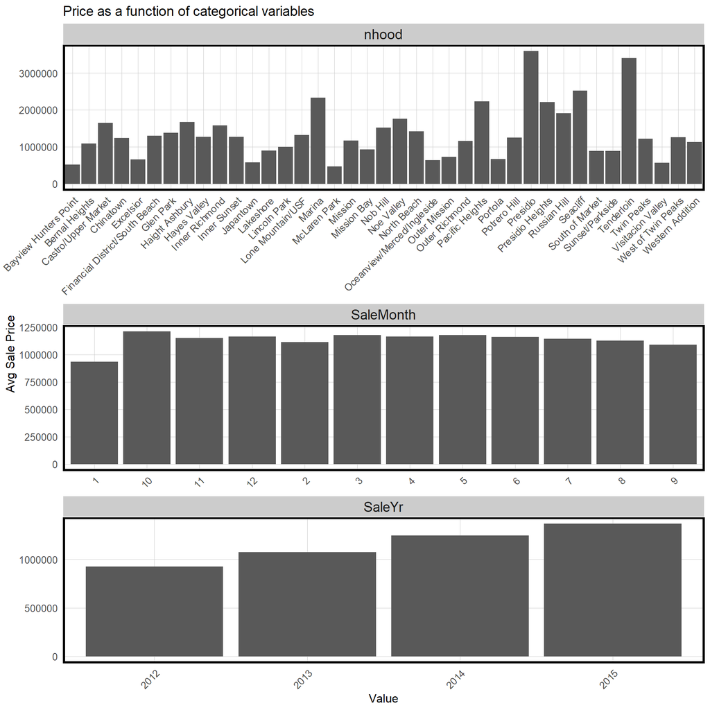

```r
final_sales_categorical_only <- final_sales %>%
  dplyr::select(SalePrice, which(sapply(., is.character)), which(sapply(., is.factor))) %>%
  dplyr::select(SalePrice, nhood, SaleYr, SaleMonth)

final_sales_categorical_only %>%
  as.data.frame() %>%
  dplyr::select(-geometry) %>%
  gather(Variable, Value, -SalePrice) %>%
   ggplot(aes(x = Value,
              y = SalePrice)) +
     geom_bar(stat = "summary", fun.y = "mean", position = "dodge") +
     facet_wrap(~Variable, ncol = 1, scales = "free") +
     labs(title = "Price as a function of categorical variables",
          y = "Avg Sale Price") +
     theme(axis.text.x = element_text(angle = 45, hjust = 1)) +
     plotTheme() + scale_y_continuous()
```

## Independent Variables – Spatial Distribution

Home sales don’t show much clustering by year. They are fairly evenly distributed around the city across all four years in the study period.

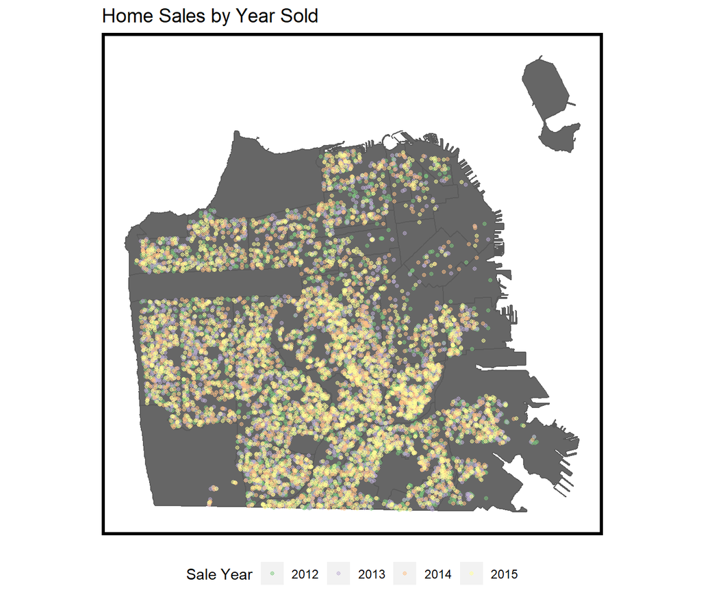

```r
  ggplot() +
    geom_sf(data = neighbs, fill = "grey40") +
    geom_sf(data = final_sales, aes(colour = SaleYr), show.legend = "point", size = 1, alpha = 0.5) +
    scale_colour_manual(values = c("2012" = "#7fc97f",
                                   "2013" = "#beaed4",
                                   "2014" = "#fdc086",
                                   "2015" = "#ffff99"),
                     name = "Sale Year") +
    labs(title = "Home Sales by Year Sold") +
    mapTheme() + theme(legend.position = "bottom")
```

Mapping home sales by the average household income of their census tract shows a similar spatial distribution to the map of home sales by sale price. We do seem some differences, however, like in the southeast and northwest of the city.

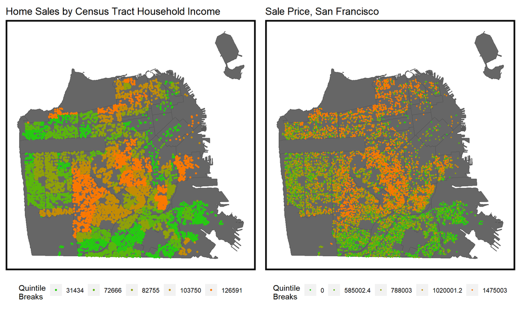

```r
grid.arrange(
  ggplot() +
    geom_sf(data = neighbs, fill = "grey40") +
    geom_sf(data = final_sales, aes(colour = q5(HH_Income)), show.legend = "point", size = 1) +
    scale_colour_manual(values = palette5,
                     labels = qBr(final_sales, "HH_Income"),
                     name = "Quintile\nBreaks") +
    labs(title = "Home Sales by Census Tract Household Income") +
    mapTheme() + theme(legend.position = "bottom"),

  SalePrice_map + theme(legend.position = "bottom"),

  ncol = 2)
```

Mapping each property sale by its density of crimes yields the inverse of the sale price map except for downtown San Francisco in the northeast, where high home sale prices correlate with high crime density. The high density of activity in downtown may explain this discrepancy. Areas with large amounts of people and activity typically experience higher amounts of crimes.

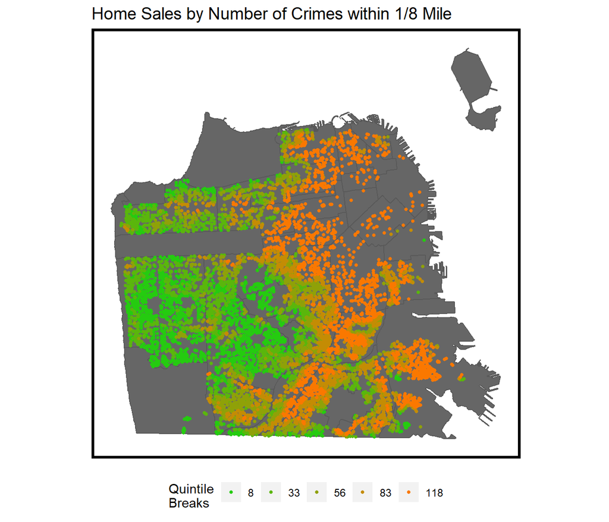

```r
  ggplot() +
    geom_sf(data = neighbs, fill = "grey40") +
    geom_sf(data = final_sales, aes(colour = q5(crimes.Buffer)), show.legend = "point", size = 1) +
    scale_colour_manual(values = palette5,
                     labels = qBr(final_sales, "crimes.Buffer"),
                     name = "Quintile\nBreaks") +
    labs(title = "Home Sales by Number of Crimes within 1/8 Mile") +
    mapTheme() + theme(legend.position = "bottom")
```

# Methods

To make our predictions for sale price, we created a **multiple linear regression model**. After constructing our features for each home sale, we split the data into a **training set (60%) and a test set (40%)**. We used the training set to teach the model a relationship between the various explanatory variables we analyzed and the home’s sale price. We removed factors with no or minimal predictive power and further refined other features to be better predictors. We then used this model to predict the prices on the test set, and we evaluated our model based on how well it predicted the sale prices for the test set. We used **k-folds cross-validation** to test our model’s consistency – by repeating the training set/test set split 100 times, we could see how reliably our model produced predictions with a certain level of accuracy.

## Dealing with Missing Data

Some of our data were incomplete. We did not include variables that were missing a significant percentage of their observations, such as the number of bedrooms. For variables missing a smaller percentage of their observations, such as property area, we imputed values using the neighborhood average.

Imputing values for variables is an important step in the process. Linear regression models can only be trained on observations with information for every explanatory variable. Our model includes 12 explanatory variables, each of which has some number of missing values. Since our sample is about 9,500 home sales, we could simply remove the incomplete observations and still have a large enough sample size to train the model. Doing so, however, may introduce a systematic bias into our model, since observations with NA values for a variable may share a common characteristic that is relevant to sale price. Removing those observations from our data set would mean our model is not trained to recognize the relevance of those characteristics to sale price.

# Results

## Training Set Model Results

The table below shows the results of the multiple linear regression that we ran on our training data. Note again that we trained the model to predict the log of sale price. Getting the final sale price prediction requires exponentiating the predicted log of sale price value.

Interpretation:

- **Continuous Variables (e.g. PropArea):** For every additional square foot of property area, the log of Sale Price goes up about 0.0003.
- **Categorical Variables (e.g., nhoodBernal Heights):** A property located in Bernal Heights is expected to have a log of Sale Price about 0.319 higher than a house sold in Bayview Hunters Point, the reference neighborhood.
- **Adjusted R-Squared:** The variables in our model account for 77.4% of the variation in the log of Sale Price in the training set.

```r
stargazer(training_reg, header = FALSE, type = "html", notes.append = FALSE,
          notes = c("<sup>&sstarf;</sup>p<0.1; <sup>&sstarf;&sstarf;</sup>p<0.05; <sup>&sstarf;&sstarf;&sstarf;</sup>p<0.01"),
          dep.var.labels   = "log Sale Price")
```

|  | *Dependent variable:* |
| --- | --- |
|  | log Sale Price |
| PropArea | 0.0003*** |
|  | (0.00001) |
| Rooms | -0.010*** |
|  | (0.003) |
| SaleYr2013 | 0.188*** |
|  | (0.009) |
| SaleYr2014 | 0.342*** |
|  | (0.010) |
| SaleYr2015 | 0.482*** |
|  | (0.010) |
| SaleMonth2 | 0.068*** |
|  | (0.021) |
| SaleMonth3 | 0.077*** |
|  | (0.019) |
| SaleMonth4 | 0.115*** |
|  | (0.019) |
| SaleMonth5 | 0.160*** |
|  | (0.019) |
| SaleMonth6 | 0.152*** |
|  | (0.019) |
| SaleMonth7 | 0.166*** |
|  | (0.019) |
| SaleMonth8 | 0.137*** |
|  | (0.019) |
| SaleMonth9 | 0.150*** |
|  | (0.019) |
| SaleMonth10 | 0.178*** |
|  | (0.018) |
| SaleMonth11 | 0.181*** |

[output cut: 101 more lines]

## Test Set Prediction Results

The table below shows some statistics assessing the quality of our predictions on the test set.

- **MAE:** On average, our predictions were off by about $220,000. Note that the average home in our dataset sold for $1.14 million.
- **MAPE:** On average, our predictions were off by about 20%.
- **R-Squared:** Our model accounted for 68% of the variation in the sale price in the test set.

```r
MAE <- st_set_geometry(sales.test_predict, NULL) %>%
  summarize(mean(SalePrice.AbsError, na.rm = T)) %>%
  pull()

MAPE <- st_set_geometry(sales.test_predict, NULL) %>%
  summarize(mean(SalePrice.APE, na.rm = T) * 100) %>%
  round(2)

R2 <- cor(sales.test_predict$SalePrice, sales.test_predict$SalePrice.Predict, method = "pearson") ^ 2

test_set_kable <- data.frame(MAE, MAPE, R2)

kable(test_set_kable,
      col.names = c("MAE", "MAPE", "R-Squared"),
      caption = "Error Values and R-Squared for Test Set Predictions") %>%
  kable_styling(full_width = F, position = "left")
```

Error Values and R-Squared for Test Set Predictions

| MAE | MAPE | R-Squared |
| --- | --- | --- |
| 221021.8 | 20.32 | 0.6791686 |

## Cross-Validation Results

Our cross-validation results show evaluation statistics *after transforming our predicted log sale price values* back into *regular sale prices*. The model has some issues with consistency. The standard deviation of Mean Average Percent Error (MAPE) across the 100 folds, for instance, is nearly 1/3 of the average MAPE.

```r
resamples <- data.frame(table(lapply(reg.cv$control$indexOut, length))) %>%
  dplyr::select(-Freq) %>%
       gather(Fold, Obs) %>%
  mutate(Obs = as.numeric(Obs))

folds <- vector()

for (blah in resamples$Fold) {

  bloop <- rep(blah, times = resamples %>% filter(Fold == blah) %>% pull(Obs))
  folds <- c(folds, bloop)

}

CV_results <- data.frame(Fold = folds,
      log_SalePrice = reg.cv$finalModel$model$.outcome,
      SalePrice = exp(reg.cv$finalModel$model$.outcome),
      log_SalePrice.Predict = reg.cv$finalModel$fitted.values,
      SalePrice.Predict = exp(reg.cv$finalModel$fitted.values)) %>%
  mutate(AE = abs(SalePrice.Predict - SalePrice),
         APE = abs(SalePrice.Predict - SalePrice) / SalePrice) %>%
  group_by(Fold) %>%
  dplyr::summarize(MAE = mean(AE),
            MAPE = mean(APE),
            R2 = cor(SalePrice.Predict, SalePrice) ^ 2)

CV_kable <- data.frame(Mean_MAE = mean(CV_results$MAE),
                       SD_MAE = sd(CV_results$MAE),
                       Mean_MAPE = round(mean(CV_results$MAPE), 2) * 100,
                       SD_MAPE = round(sd(CV_results$MAPE), 2) * 100,
                       Mean_R2 = round(mean(CV_results$R2), 2),
                       SD_R2 = round(sd(CV_results$R2), 2))

kable(CV_kable,
      col.names = c("Average MAE", "Std Deviation of MAE", "Average MAPE",
                    "Std Deviation of MAPE", "Average R-Squared", "Std Deviation of R-Squared"),
      caption = "100-fold Cross-Validation Results") %>%
  kable_styling(full_width = F)
```

100-fold Cross-Validation Results

| Average MAE | Std Deviation of MAE | Average MAPE | Std Deviation of MAPE | Average R-Squared | Std Deviation of R-Squared |
| --- | --- | --- | --- | --- | --- |
| 222019.4 | 119063.9 | 20 | 6 | 0.68 | 0.1 |

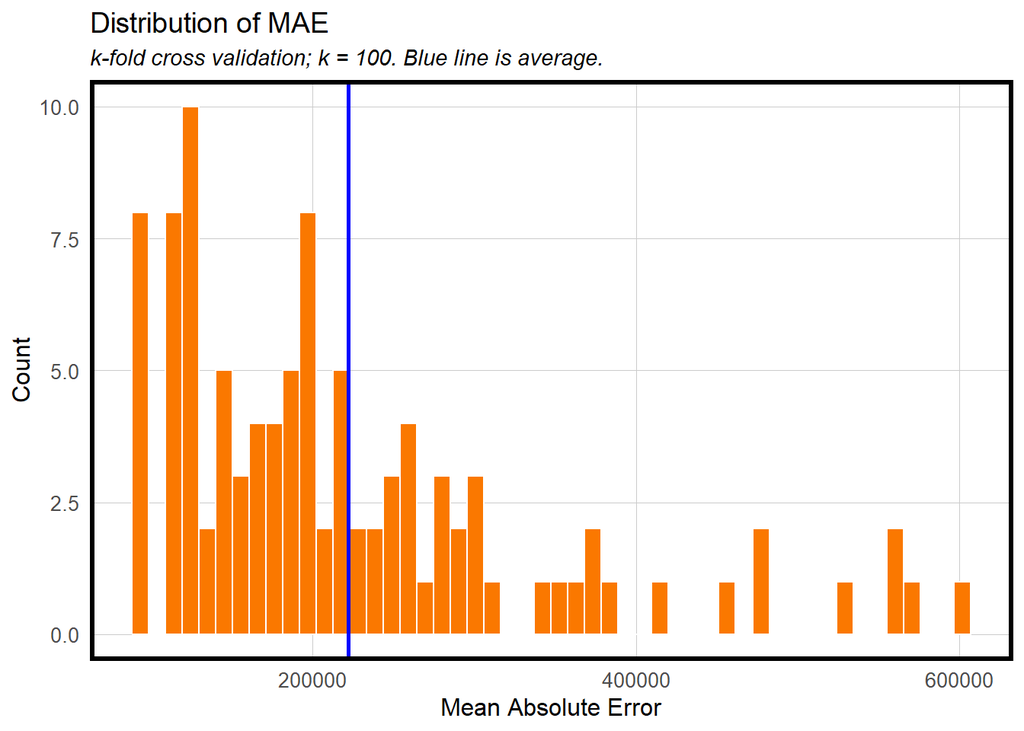

```r
ggplot(CV_results, aes(MAE)) +
  geom_histogram(bins = 50, colour="white", fill = "#FA7800") +
  geom_vline(aes(xintercept = mean(MAE)), color = "blue", size = 1) +
  labs(title = "Distribution of MAE", subtitle = "k-fold cross validation; k = 100. Blue line is average.",
       x = "Mean Absolute Error", y = "Count") +
  plotTheme() + scale_x_continuous()
```

## Plot of Prediction results

Our model included several very high overpredictions, including one prediction of nearly $12,000,000. These overpredictions have an outsized effect on our evaluation metrics and our goodness-of-fit line below (the green line). Refining our model with features that limit the number of these overpredictions would likely significantly improve the predictive power of our model.

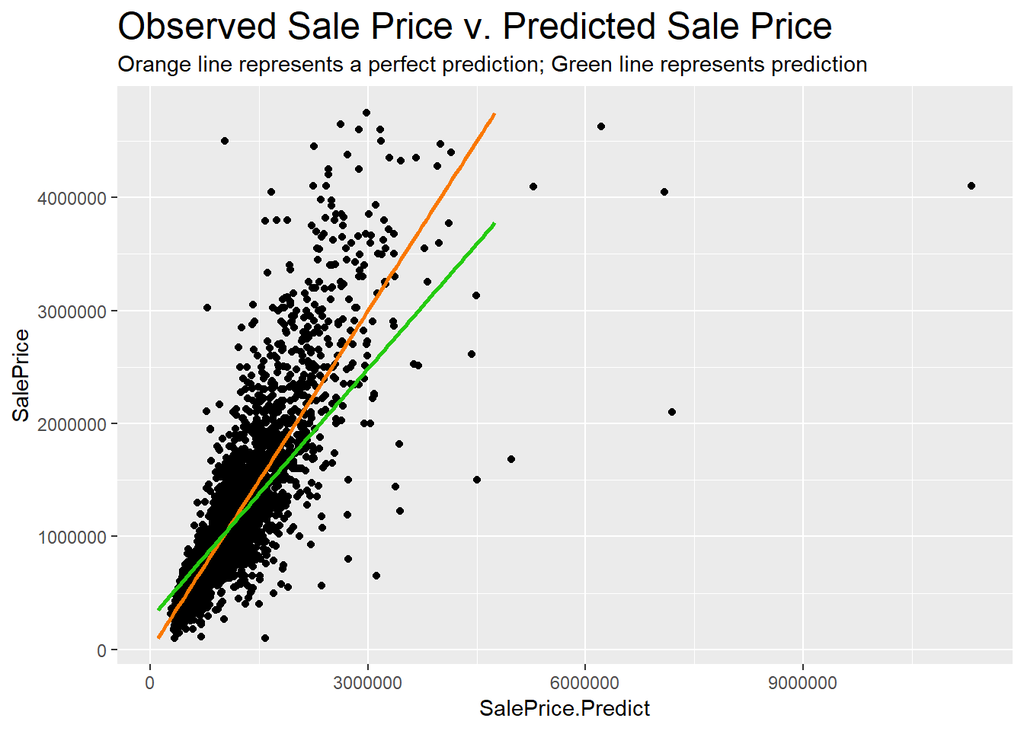

```r
ggplot(sales.test_predict, aes(SalePrice.Predict, SalePrice)) +
  geom_point() +
  stat_smooth(data = sales.test_predict, aes(SalePrice, SalePrice),
             method = "lm", se = FALSE, size = 1, colour="#FA7800") +
  stat_smooth(data = sales.test_predict, aes(SalePrice, SalePrice.Predict),
              method = "lm", se = FALSE, size = 1, colour="#25CB10") +
  labs(title="Observed Sale Price v. Predicted Sale Price",
       subtitle="Orange line represents a perfect prediction; Green line represents prediction") +
  theme(plot.title = element_text(size = 18,colour = "black"))
```

## Map of Prediction Results

Visually, our predictions align well with the actual sale prices. Our model does seem to underprice some of the more expensive homes that are found sporadically throughout the southern part of the city.

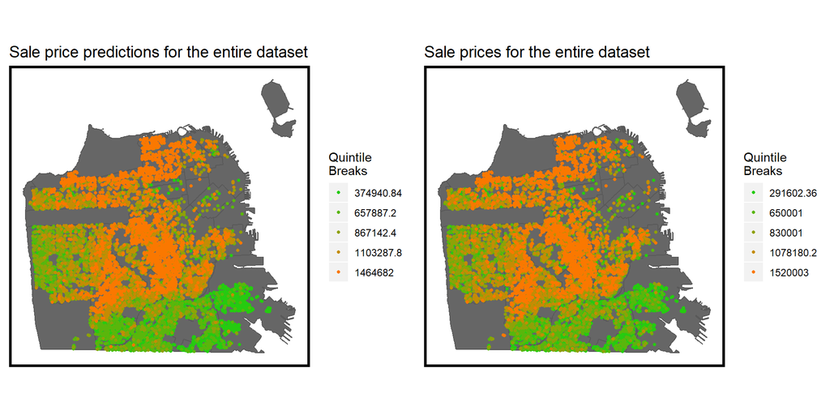

```r
sales.predict_all <-
  final_sales_all %>%
  # need to exponentiate since we predicted log sale price
  mutate(SalePrice.Predict = predict(training_reg, final_sales_all, na.action=na.pass) %>% exp(),
         SalePrice.Error = SalePrice - SalePrice.Predict,
         SalePrice.AbsError = abs(SalePrice - SalePrice.Predict),
         SalePrice.APE = (abs(SalePrice - SalePrice.Predict)) / SalePrice)

grid.arrange(
  ggplot() +
      geom_sf(data = neighbs, fill = "grey40") +
      geom_sf(data = sales.predict_all, aes(colour = q5(SalePrice.Predict)), show.legend = "point", size = 1) +
      scale_colour_manual(values = palette5,
                       labels = qBr(sales.predict_all, "SalePrice.Predict"),
                       name = "Quintile\nBreaks") +
      labs(title = "Sale price predictions for the entire dataset") +
      mapTheme(),

  ggplot() +
      geom_sf(data = neighbs, fill = "grey40") +
      geom_sf(data = final_sales, aes(colour = q5(SalePrice)), show.legend = "point", size = 1) +
      scale_colour_manual(values = palette5,
                       labels = qBr(final_sales, "SalePrice"),
                       name = "Quintile\nBreaks") +
      labs(title = "Sale prices for the entire dataset") +
      mapTheme(),

  ncol = 2)
```

## Map of Test Set Residuals

Our test set residuals (the difference between our predicted price and the actual price) do not appear to show spatial clustering. At first glance, our model does not exhibit much spatial bias.

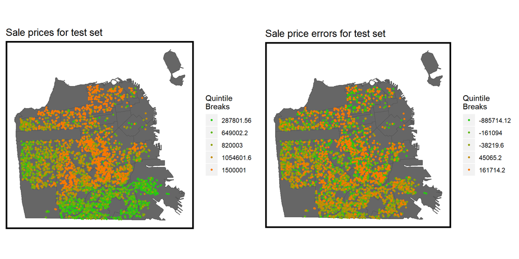

```r
grid.arrange(
  ggplot() +
      geom_sf(data = neighbs, fill = "grey40") +
      geom_sf(data = sales.test_predict, aes(colour = q5(SalePrice)), show.legend = "point", size = 1) +
      scale_colour_manual(values = palette5,
                       labels = qBr(sales.test_predict, "SalePrice"),
                       name = "Quintile\nBreaks") +
      labs(title = "Sale prices for test set") +
      mapTheme(),

  ggplot() +
      geom_sf(data = neighbs, fill = "grey40") +
      geom_sf(data = sales.test_predict, aes(colour = q5(SalePrice.Error)), show.legend = "point", size = 1) +
      scale_colour_manual(values = palette5,
                       labels = qBr(sales.test_predict, "SalePrice.Error"),
                       name = "Quintile\nBreaks") +
      labs(title = "Sale price errors for test set") +
      mapTheme(),
ncol = 2)
```

Our calculated Moran’s I of 0.041 shows that our test set residuals are very slightly clustered. The p-value of 0.001 shows that this small amount of clustering is greater than would be expected through random chance alone.

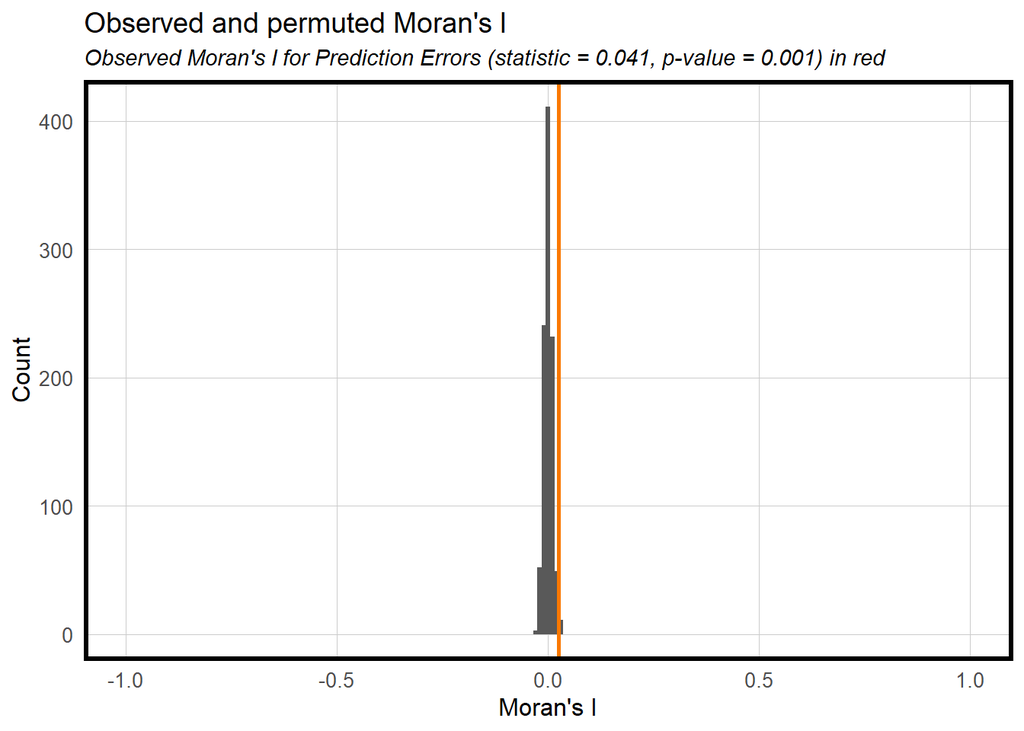

```r
coords.test <- sales.test_predict %>%
  st_coordinates()

neighborList.test <- knn2nb(knearneigh(coords.test, 5))

spatialWeights.test <- nb2listw(neighborList.test, style="W")

sales.test_predict$lagPriceError <- lag.listw(spatialWeights.test, sales.test_predict$SalePrice.Error)

moranTest <- moran.mc(sales.test_predict$SalePrice.Error,
                      spatialWeights.test , nsim = 999)

ggplot(as.data.frame(moranTest$res[c(1:999)]), aes(moranTest$res[c(1:999)])) +
  geom_histogram(binwidth = 0.01) +
  geom_vline(aes(xintercept = moranTest$statistic), colour = "#FA7800",size=1) +
  scale_x_continuous(limits = c(-1, 1)) +
  labs(title="Observed and permuted Moran's I",
       subtitle= "Observed Moran's I for Prediction Errors (statistic = 0.041, p-value = 0.001) in red",
       x="Moran's I",
       y="Count") +
  plotTheme()
```

## Map of MAPE by Neighborhood

Our MAPE tended to be higher in those neighborhoods with higher home sale prices. If using a similar model to assess homes for tax purposes, these errors could result in a more volatile revenue stream.

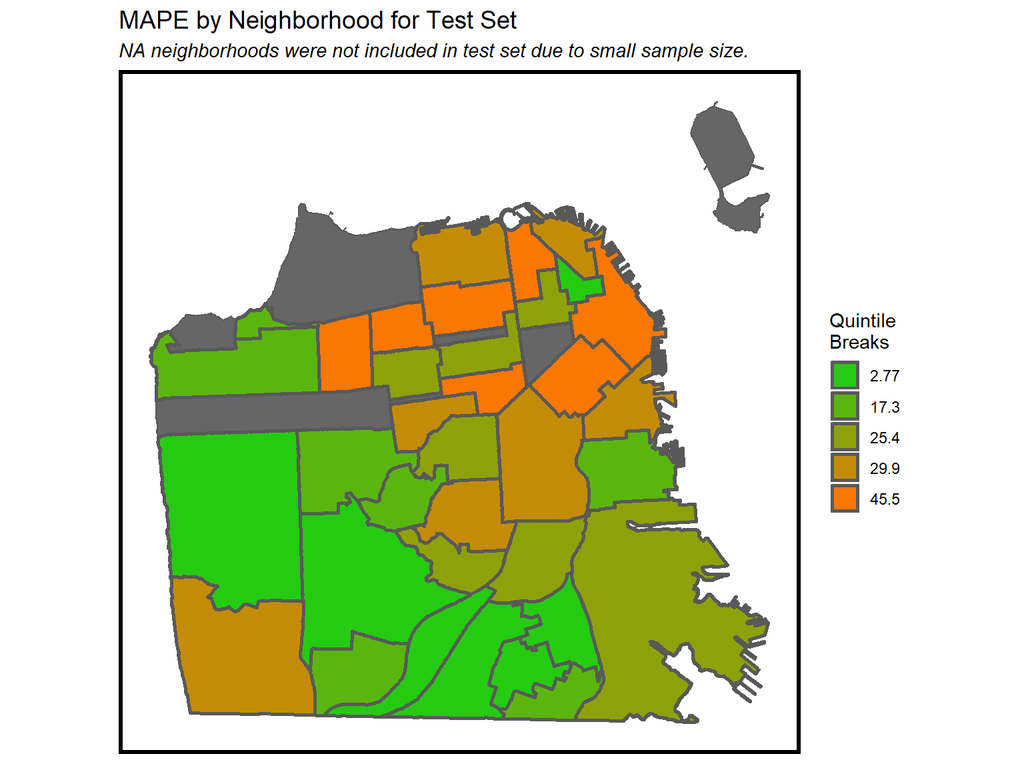

```r
sales.test_predict_neighb_MAPE <- sales.test_predict %>%
  group_by(nhood) %>%
  summarize(SalePrice = mean(SalePrice),
            MAPE = mean(SalePrice.APE))

sales.test_predict_neighb_MAPE <- dataHere %>% st_join(sales.test_predict_neighb_MAPE) %>%
  filter(!is.na(MAPE))

ggplot() +
    geom_sf(data = neighbs, fill = "grey40") +
    geom_sf(data = sales.test_predict_neighb_MAPE %>%
                                    filter(!is.na(MAPE)), aes(fill = q5(MAPE)), size = 1) +
    scale_fill_manual(values = palette5,
                     labels = qBr(sales.test_predict_neighb_MAPE %>%
                                    filter(!is.na(MAPE)) %>%
                                    mutate(MAPE = MAPE * 100), "MAPE", rnd = FALSE),
                     name = "Quintile\nBreaks") +
    labs(title = "MAPE by Neighborhood for Test Set",
         subtitle = "NA neighborhoods were not included in test set due to small sample size.") +
    mapTheme()
```

## Scatterplot of Average Neighborhood MAPE as a Function of Home Sale Price

Our model generally gets worse at predicting prices as neighborhoods get wealthier.

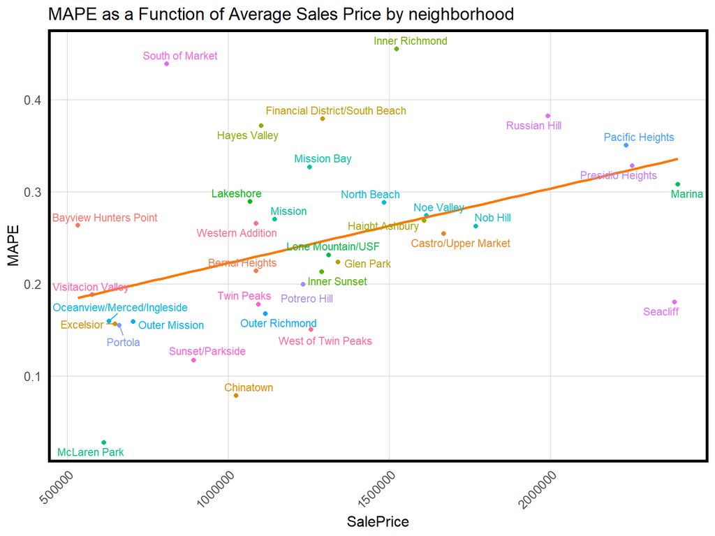

```r
sales.test_predict_neighb_MAPE %>%
  ggplot(aes(x = SalePrice,
             y = MAPE,
             color = nhood.x,
             label = nhood.x)) +
    geom_point() +
     geom_smooth(method = "lm", se = F, colour = "#FA7800") +
      ggrepel::geom_text_repel(size = 3) +
     labs(title = "MAPE as a Function of Average Sales Price by neighborhood") +
     theme(axis.text.x = element_text(angle = 45, hjust = 1)) +
     plotTheme() +
  theme(legend.position = "none")
```

## Generalizability across Race and Income

San Francisco’s higher earning population generally lives in majority white neighborhoods. Exceptions include the moderately priced Sunset area and parts of SoMa and Mission Bay.

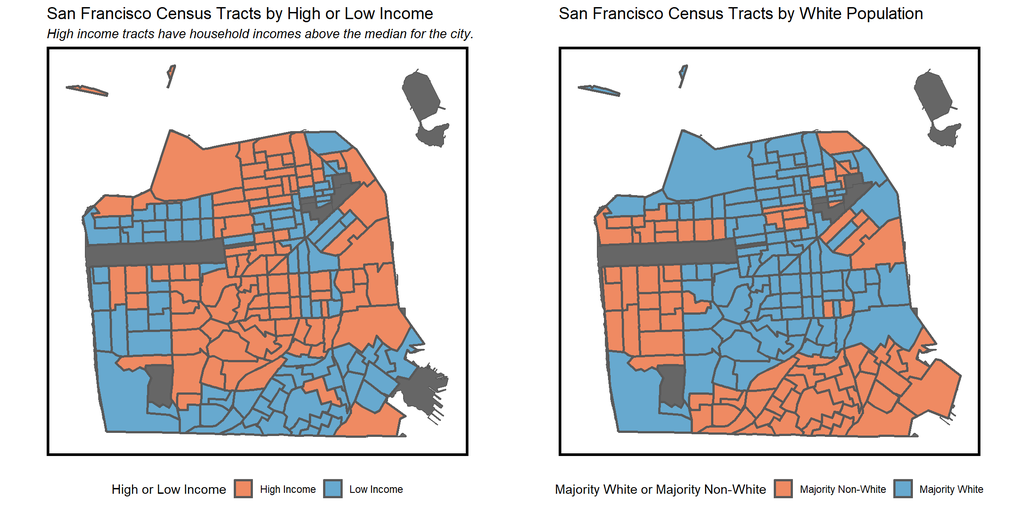

```r
all_census_income <- all_census[dataHere, ] %>%
  filter(GEOID %in% final_sales_all$Tract) %>%
  mutate(incomeContext = ifelse(HH_Income > median(HH_Income, na.rm = TRUE), "High Income", "Low Income"),
         raceContext = ifelse(White_Pct > 50, "Majority White", "Majority Non-White"))


grid.arrange(
ggplot() +
    geom_sf(data = neighbs, fill = "grey40") +
    geom_sf(data = all_census_income %>% filter(!is.na(incomeContext)), aes(fill = incomeContext), size = 1) +
    scale_fill_manual(values = c("#ef8a62", "#67a9cf"),
                     name = "High or Low Income") +
    labs(title = "San Francisco Census Tracts by High or Low Income",
         subtitle = "High income tracts have household incomes above the median for the city.") +
    mapTheme() + theme(legend.position = "bottom"),

ggplot() +
    geom_sf(data = neighbs, fill = "grey40") +
    geom_sf(data = all_census_income %>% filter(!is.na(raceContext)), aes(fill = raceContext), size = 1) +
    scale_fill_manual(values = c("#ef8a62", "#67a9cf"),
                     name = "Majority White or Majority Non-White") +
    labs(title = "San Francisco Census Tracts by White Population",
         subtitle = "") +
    mapTheme() + theme(legend.position = "bottom"),

ncol = 2)
```

Using the categories mapped above, we see that our model is more accurate at predicting home costs in lower income and majority non-white neighborhoods. The disparity between predictions in non-white and white neighborhoods is especially dramatic, with prediction in white neighborhoods over 40% more inaccurate than in non-white neighborhoods (MAPE of 23.9% versus 16.6%).

```r
sales.test_predict_income <- sales.test_predict %>%
  mutate(incomeContext = ifelse(HH_Income > median(HH_Income, na.rm = TRUE), "High Income", "Low Income")) %>%
  group_by(incomeContext) %>%
  summarize(MAE = mean(SalePrice.AbsError),
            MAPE = mean(SalePrice.APE)) %>%
  st_set_geometry(NULL) %>%
  rename(Context = incomeContext)


sales.test_predict_race <- sales.test_predict %>%
  mutate(raceContext = ifelse(White_Pct > 50, "Majority White", "Majority Non-White")) %>%
  group_by(raceContext) %>%
  summarize(MAE = mean(SalePrice.AbsError),
            MAPE = mean(SalePrice.APE)) %>%
  st_set_geometry(NULL) %>%
  rename(Context = raceContext)

rbind(sales.test_predict_income, sales.test_predict_race) %>%
  kable(caption = "Errors for test set sale price predictions by neighborhood racial and income contexts") %>%
    kable_styling("striped", full_width = F, position = "left") %>%
    row_spec(1, color = "black", background = "#25CB10") %>%
    row_spec(2, color = "black", background = "#25CB10") %>%
    row_spec(3, color = "black", background = "#FA7800") %>%
    row_spec(4, color = "black", background = "#FA7800")
```

Errors for test set sale price predictions by neighborhood racial and income contexts

| Context | MAE | MAPE |
| --- | --- | --- |
| High Income | 293604.9 | 0.2150171 |
| Low Income | 148631.6 | 0.1914742 |
| Majority Non-White | 117592.8 | 0.1661998 |
| Majority White | 321145.7 | 0.2390770 |

**Is your model generalizable?**

Our model is not perfectly generalizable. It is more accurate at assessing home sale prices in low income and majority non-white neighborhoods. Why is this a concern? If this model (or one similar) was used to assess homes for property tax purposes, it could overcharge wealthier neighborhoods for public services. This is definitely preferable to the alternative: the long-standing discriminatory practice of placing a higher tax burden on minorities through inflated assessments in lower income, majority-minority neighborhoods. However, this makes the model non-generalizable and would probably lead to some angry wealthy homeowners.

# Discussion

**Is this an effective model?**

**What were some of the more interesting variables? Describe the more important predictor variables.**

Sale year and month were surprisingly predictive. This was because of the focus years of our study: 2012-2015. As the housing market in San Francisco has grown from competitive to astronomically exclusive, prices have steadily increased to reflect the constrained supply.

Our most predictive variables were actually quite foreseeable. Size, median household income of the census tract a home was in, and susceptibility to crime were some of the most predictive factors.

**According to your maps, could you account for the spatial variation in prices? Where did the model predict particularly well? Poorly? Why do you think this might be?**

While the map of sale price shows that higher price homes are clearly clustered in particular neighborhoods, the map of our sale price prediction errors did not show similar clustering. This is quantified by the Moran’s I test of the errors which shows a Moran’s I of slightly above 0, indicating that our model accounted for much of the spatial variation in prices.

# Conclusion

**Would you recommend your model to Zillow? Why or why not? How might you improve this model?**

Zillow publishes limited assessments of its Zestimate accuracy. In their [latest report](https://www.zillow.com/zestimate/) from June of 2019, their predictions for off-market homes in San Francisco err only 7.2% from the actual price, making their Zestimates within 10% of the sale price in 62.4% of transactions. This is much more accurate than our predictions with a MAPE around 20%. We don’t know where Zillow’s predictions have the largest errors (homes selling for lower or higher prices), so we can’t say if Zestimates have the issue as we did with predicting the home sales in the upper quartile.

One thing our model lacked is robust information on the internal characteristics of the homes we were analyzing. We knew very little about the improvements made to homes over time (or before listing) that would have a large impact of their selling price when put on the market. Even more information about who was selling them – long-term owners, banks, or LLCs – would have informed our model in interesting ways. From this, we could garner more information about the physical investment in both the individual homes and the neighborhoods they are in to better inform our model.